# lez_lm_a: i modelli lineari. La Teoria

## Il modello lineare

### Questo sconosciuto

## Quasi tutta la statistica è un modello lineare

### ma nessuno lo dice

Il termine modello lineare è un termine così vasto da includere una granparte della statistica.

Il nostro primo obbiettivo è di connettere questi concetti in modo che si spieghino a vicenda.

In termini pratici si può definire "modello lineare" qualsiasi tentativo di connettere delle variabili esplicative (**indipendenti**) con delle variabili risultanti (**dipendenti**).

Il modello lineare generale (*General Linear Model o GLM*) prevede che la variabile dipendente sia **continua** (ovvero **quantitativa**), questi modelli (o test, a seconda del punto di vista) sono detti **parametrici**.

## 1. GLM con pendenza nulla

### *anche noto come media aritmetica*

Il nostro obbiettivo può essere visto in due modi diversi, ma matematicamente identici:

1. Individuare come **delle cause** concorrano a determinare **una conseguenza**.
2. Riuscire a **indovinare** i valori della variabile **dipendente** sapendo i valori delle variabili **indipendenti**.

Quello che io ho sono \(n\) misure \(Y_i\) (come al solito è bene iniziare a familiarizzare con la terminologia, almeno un minimo), quindi \(Y_1, Y_2, Y_3...Y_n\).

Queste misure le possiamo scrivere come: \[Y_i = \beta_0 + \epsilon_i\]

È importante notare che \(\beta\) (*beta*) ha uno zero al pedice, indicando che è un numero fisso, mentre la \(\epsilon\) (*epsilon*) ha la \(i\), intendendo che ha un valore diverso per ogni misura che abbiamo fatto.

Questo modello mi dice: la \(Y\) dovrebbe essere \(\beta_0\), poi c'è il fatto che il mondo è complicato, e quello finisce tutto nella "correzione" \(\epsilon\), chiamato **errore**.

Quindi la "stima" (o in termini tecnici: lo **stimatore**) delle mie misure è: \[\hat{Y}_i = \beta_0\]

## Una parentesi sui **metodi**

Mettiamo un attimo da parte i modelli e consideriamo un altro problema: conoscendo l'altezza di tutti gli alunni di una classe, voglio identificare (**stimare**) il numero che mi fa andare più vicino alla misura giusta se scommettessi sempre sulla stessa altezza.

Il problema diventa immediatamente: **cosa vuol dire andare più vicino al risultato esatto in una serie di misure?**

È chiaro che cosa vuol dire più vicino in una misura: che la differenza fra il valore ipotizzato e quello reale (chiamiamolo **scarto**) è la minore possibile. Ma in **più misure?**

In questo caso parliamo di **metodi**, ovvero di tecniche matematiche che ci aiutano a indovinare (**stimare**), i parametri (di un modello) che utilizziamo per indovinare (**stimare**) la mia grandezza di interesse.

Quindi come identifichiamo chi si è sbagliato meno?

Una risposta elementare può essere: **chi ha la somma delgli scarti (\(\sum_{i=1}^n\epsilon_i\)) più bassa**.

Questo sembra un buon sistema, ma fa schifo.

\[WHY?\]

La seconda risposta più elementare può essere (considerando due errori piccoli meglio di uno grande), che ci è andato più vicino **chi ha la somma *dei quadrati degli scarti* (\(\sum_{i=1}^n \epsilon_i^2\)) più bassa**

Questo metodo è quasi universalmente considerato il top della vita, si è guadagnato un nome: **Metodo dei Minimi Quadrati** e un acronimo **OLS** (*Ordinary Least Squares*).

- è chiaro
- è semplice da calcolare (anche a mano volendo)
- non riserva sorprese
- gli assunti che fa sui dati sono quasi sempre rispettati (e se non lo sono si mette male, il metodo è l'ultimo dei vostri problemi)

Ora questo valore che minimizza i quadrati degli scarti, per una serie di numeri di cui io non so nulla, è matematicamente identico, e quindi **la stessa cosa** del calcolo della media aritmetica.

E questo di fatto ci rende molto felici: tutto torna, il valore costante che si avvicina di più a tutti i valori che ho misurato è la loro **media aritmetica**

**N.B. vale la pena notare che la somma del quadrato degli errori diviso il numero delle misure** \[\frac{\sum_{i=1}^N\epsilon_i^2}{N}\]

**che viene minimizzata trovando la media, è la VARIANZA (\(\sigma^2\))**

## Torniamo ai modelli lineari

Il modello più elementare che possiamo realizzare è quello che dà come risultato una retta orizzontale:

```
##
## Call:
## lm(formula = wt ~ 1, data = mtcars)
##
## Coefficients:
## (Intercept)
##       3.217
```

Quello che abbiamo chiesto è: **un valore che non vari con nessuna variabile** che mi consenta di predire il risultato della variabile **dipendente**.

Il **metodo** utilizzato di default dai modelli lineari è, guardacaso, l'**OLS**.

possiamo facilmente controllare che **l'intercetta** (ovvero il valore della retta quando \(x=0\)) è uguale alla **media** dei valori della variabile dipendente:

```
##
## Call:
## lm(formula = wt ~ 1, data = mtcars)
##
## Coefficients:
## (Intercept)
##       3.217
```

```
## [1] 3.21725
```

Il mio modello lineare ha questa faccia:

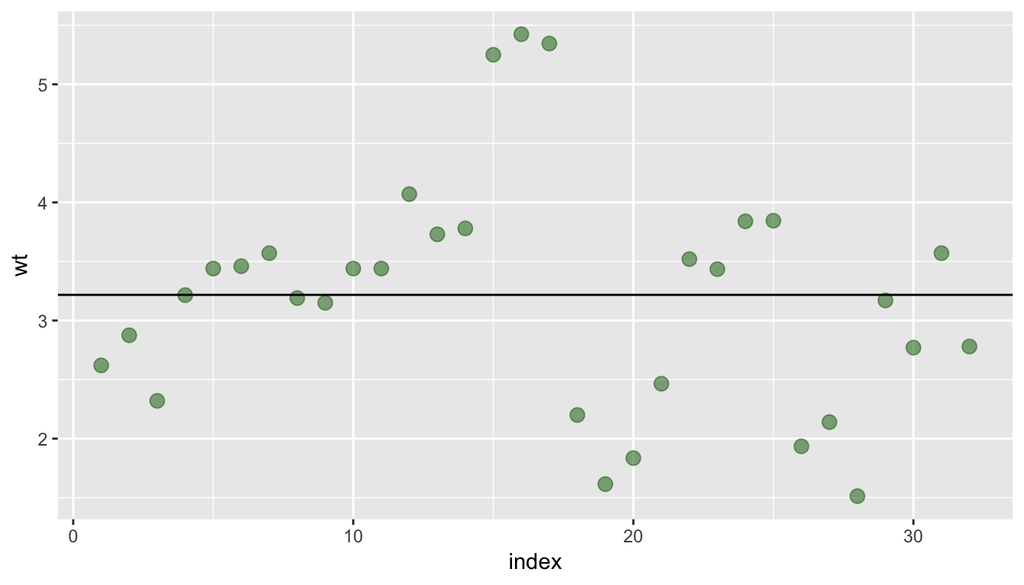

sull'asse delle ho \(X\) dei valori sequanziali, che mi tengono i punti staccati uno dall'altro, sull'asse \(Y\) ci sono i valori della mia variabile, e **l'altezza** della retta che cerca di riassumere i miei punti è l'**intercetta**, e usando gli **OLS** anche la media.

Gli \(\epsilon_i\), possono eseere visti sul grafico come le lunghezze delle linee rose:

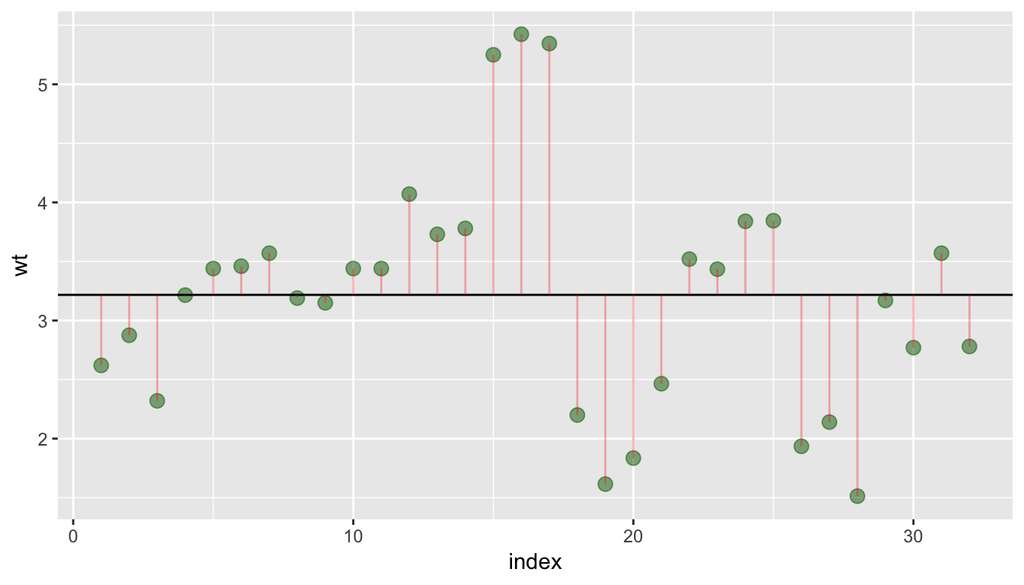

A questo punto potremmo chiederci qual'è l'intervallo di confidenza dell'intercetta.

Cosa significa?

Ricordiamoci che se il nostro è un campione (e non l'intera popolazione), la sua media non sarà la media della popolazione, ma solo **una stima** della media della popolazione.

Questa stima sarà tanto migliore più il campione sarà grande, inoltre un campione piuttosto omogeneo suggerisce anche una popolazione piuttoto omogenea, e quindi una stima migliore.

L'intervallo di confidenza viene calcolato secondo la \(t\) di Student.